# S1: behavioural, conventional analysis with brms

I. S. Plank

2025-09-15

# 1 Task info and setup

This R Markdown script analyses data from the PAL (probabilistic associative learning) task of the EMBA project. It focuses on the comparison of adults with ASD and adults without psychiatric diagnoses. The data was preprocessed before being read into this script.

In this task, participants view faces for which they have to judge whether the portrayed emotion is positive or negative. The faces are preceded by a tone which is predictive of the valence of the following face. The visual angle of the faces was 3.46 degrees wide and 4.72 degrees high.

## 1.1 Plot the development of associations across task

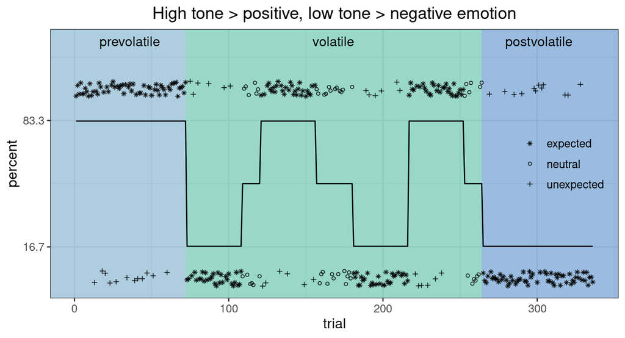

```r
# load the trial order
df.trl = read_csv('../data/PAL_scheme.csv', show_col_types = F) %>%
  mutate(
    association = ut*100,
    prob_HP = prob_HP*100
  )

# create rectangles to colour the phases: prevolatile, volatile and postvolatile
rects = data.frame(xstart = c(-Inf, 72, 264),
                   xend = c(72, 264, Inf),
                   col = c("a", "b", "c"))

ggplot() +
  geom_rect(data = rects, aes(xmin = xstart, xmax = xend,
                              ymin = -Inf, ymax = Inf,
                              fill = col), alpha = 0.4) +
  scale_fill_manual(values=c(c_mid_highlight, c_green, c_dark_highlight),
                    guide = "none") +
  geom_jitter(data = df.trl,
              aes(x = trl, y = association, shape = expected),
              colour = "black", alpha = 0.8, size = 1, width = 0, height = 4) +
  geom_line(data = df.trl,
            aes(x = trl, y = prob_HP),
            colour = "black") +
  scale_shape_manual(values = c(8, 1, 3)) +
  theme_bw() +
  scale_y_continuous(breaks=c(16.7, 83.3)) +
  labs(x = "trial", y = "percent",
       title = "High tone > positive, low tone > negative emotion") +
  annotate("text", x = 36, y = 125, label= "prevolatile", size = 4) +
  annotate("text", x = 168, y = 125, label= "volatile", size = 4) +
  annotate("text", x = 301, y = 125, label= "postvolatile", size = 4) +
  theme(legend.position = c(0.9, 0.5), legend.title = element_blank(),
        legend.background = element_rect(fill = alpha("white", 0)),
        legend.key = element_rect(fill = alpha("white", 0)),
        plot.title = element_text(hjust = 0.5), text = element_text(size = 12))
```

```r
ggsave("plots/PAL_scheme.png",
       units = "cm",
       width = 27,
       height = 9)
```

## 1.2 Some general settings

```r
# number of simulations
nsim = 250

# set number of iterations and warmup for models
iter = 6000
warm = 1500

# set the seed
set.seed(2468)
```

## 1.3 Package versions

The following packages are used in this RMarkdown file:

```
## [1] "R version 4.5.0 (2025-04-11)"
```

```
## [1] "knitr version 1.50"
## [1] "ggplot2 version 3.5.2"
## [1] "brms version 2.22.0"
## [1] "bridgesampling version 1.1.2"
## [1] "tidyverse version 2.0.0"
## [1] "ggpubr version 0.6.0"
## [1] "ggrain version 0.0.4"
## [1] "bayesplot version 1.12.0"
## [1] "SBC version 0.3.0.9000"
## [1] "rstatix version 0.7.2"
## [1] "officer version 0.6.10"
## [1] "effectsize version 1.0.1"
## [1] "BayesFactor version 0.9.12.4.7"
## [1] "bayestestR version 0.16.0"
```

## 1.4 Analysis guidelines

We planned to determine the group-level effect subjects following Barr (2013). For each model, experiment specific priors were set based on previous literature or the task (see comments in the code).

## 1.5 Preparation

First, we load the data and combine it with demographic information including the diagnostic status of the subjects. Then, all predictors are set to sum contrasts.

```r
# check if the data file exists, if yes load it:
if (!file.exists("../data/PAL-ASD_data.RData")) {

  # get demo info for subjects
  df.sub = read_csv(file.path("/home/emba/Documents/EMBA/CentraXX", "EMBA_centraXX.csv"),
                    show_col_types = F) %>%
    mutate(
      diagnosis = as.factor(recode(diagnosis, "CTR" = "COMP"))
    )

  # set the data path
  dt.path  = "/home/emba/Documents/EMBA/BVET"
  dt.explo = "/home/emba/Documents/EMBA/BVET-explo"

  # load the preprocessed data: df.tsk
  df.tsk = rbind(readRDS(file.path(dt.path,  "PAL_tsk.rds")),
                 readRDS(file.path(dt.explo, "PAL_tsk.rds")))

  # load excluded participants (accuracy < 2/3)
  exc = c(scan(file.path(dt.path, 'PAL_exc.txt'),  what="character", sep=NULL),
          scan(file.path(dt.explo, 'PAL_exc.txt'), what="character", sep=NULL))
  df.exc = df.sub %>% filter(subID %in% exc & diagnosis %in% c("COMP", "ASD")) %>%
    select(diagnosis) %>%
    group_by(diagnosis) %>% count()

  # merge with group and focus on comparison and autistic adults
  df.tsk = merge(df.sub %>% select(subID, diagnosis),
                 df.tsk, all.y = T) %>%
    filter(diagnosis %in% c("ASD", "COMP") & !(subID %in% exc)) %>%
    droplevels() %>%
    mutate_if(is.character, as.factor)

  # only keep participants included in the study in the subject data frame
  df.sub = merge(df.tsk %>% select(subID) %>% distinct(), df.sub, all.x = T) %>%
    droplevels()

  # anonymise the data based on predetermined file > same for all data
  df.recode = read_csv(file.path("/home/emba/Documents/EMBA/BVET", "PID_anonymisation.csv"))
  recode = as.character(df.recode$subID)
  names(recode) = df.recode$PID
  df.tsk$subID = str_replace_all(df.tsk$subID, recode)

  # save the data for use with the EMBA_HGF toolbox
  df.tsk %>% select(subID, trl, diagnosis, ut, difficulty, acc, rt) %>%
    ungroup() %>%
    arrange(subID, trl) %>%
    write_csv(., file = "../data/PAL-ASD_data.csv")

  # print gender frequencies and compare them across groups
  tb.gen = xtabs(~ gender + diagnosis, data = df.sub)
  ct.full = contingencyTableBF(tb.gen,
                               sampleType = "indepMulti",
                               fixedMargin = "cols")

  # create a demographics overview
  df.demo = createDFdemo(df.sub,
                         c("age", "edu", "BDI_total", "ASRS_total", "RAADS_total", "TAS_total", "iq"),
                         "diagnosis")

  # save it all
  save(df.tsk, df.demo, ct.full, df.exc, tb.gen,
       file = "../data/PAL-ASD_data.RData")

} else {

  load("../data/PAL-ASD_data.RData")

}

# print the group of excluded participants
kable(df.exc)
```

| diagnosis | n |
| --- | --- |
| ASD | 3 |
| COMP | 2 |

```r
rm(df.exc)

# print the outcome of the two contingency tables for comparison: all participants
ct.full@bayesFactor
```

```
##                          bf error                     time         code
## Non-indep. (a=1) -0.9799892     0 Fri Sep  5 09:19:38 2025 ee3e19bc9839
```

```r
# print gender and diagnosis distribution
kable(tb.gen)
```

|  | ASD | COMP |
| --- | --- | --- |
| fem | 11 | 10 |
| mal | 11 | 12 |

```r
# drop the neutral condition for the analysis
df.pal = df.tsk %>%
  filter(expected != "neutral" & !is.na(rt.cor)) %>% droplevels() %>%
  mutate_if(is.character, as.factor) %>%
  ungroup()

# set and print the contrasts
contrasts(df.pal$diagnosis) = contr.sum(2)
contrasts(df.pal$diagnosis)
```

```
##      [,1]
## ASD     1
## COMP   -1
```

```r
contrasts(df.pal$expected) = contr.sum(2)
contrasts(df.pal$expected)
```

```
##            [,1]
## expected      1
## unexpected   -1
```

```r
contrasts(df.pal$phase) = contr.sum(3)
contrasts(df.pal$phase)
```

```
##              [,1] [,2]
## prevolatile     1    0
## volatile        0    1
## postvolatile   -1   -1
```

```r
contrasts(df.pal$difficulty) = contr.sum(3)
contrasts(df.pal$difficulty)
```

```
##           [,1] [,2]
## easy         1    0
## medium       0    1
## difficult   -1   -1
```

```r
# print final group comparisons for the paper into a Word document
read_docx() %>%
    body_add_table(df.demo %>% arrange(measurement) %>%
                         mutate(bf.log =
                                  if_else(
                                    bf.log > log(3),
                                    sprintf("%.3f*", bf.log),
                                    sprintf("%.3f", bf.log)))) %>%
    print(target = "PAL-ASD_demo.docx")
```

# 2 Reaction times in correct trials

In the preregistration, we noted the following population-level effects for the model of the reaction time variances: group, expectancy, phase and difficulty; as well as the group-level predictores subject and trials.

## 2.1 Model setup

```r
# figure out slopes for subjects
kable(head(df.pal %>% count(subID, expected)))
```

| subID | expected | n |
| --- | --- | --- |
| 10 | expected | 225 |
| 10 | unexpected | 43 |
| 11 | expected | 225 |
| 11 | unexpected | 46 |
| 13 | expected | 206 |
| 13 | unexpected | 40 |

```r
kable(head(df.pal %>% count(subID, phase)))
```

| subID | phase | n |
| --- | --- | --- |
| 10 | prevolatile | 67 |
| 10 | volatile | 139 |
| 10 | postvolatile | 62 |
| 11 | prevolatile | 70 |
| 11 | volatile | 133 |
| 11 | postvolatile | 68 |

```r
kable(head(df.pal %>% count(subID, difficulty)))
```

| subID | difficulty | n |
| --- | --- | --- |
| 10 | easy | 91 |
| 10 | medium | 89 |
| 10 | difficult | 88 |
| 11 | easy | 93 |
| 11 | medium | 89 |
| 11 | difficult | 89 |

```r
kable(head(df.pal %>% count(subID, expected, phase)))
```

| subID | expected | phase | n |
| --- | --- | --- | --- |
| 10 | expected | prevolatile | 58 |
| 10 | expected | volatile | 117 |
| 10 | expected | postvolatile | 50 |
| 10 | unexpected | prevolatile | 9 |
| 10 | unexpected | volatile | 22 |
| 10 | unexpected | postvolatile | 12 |

```r
kable(head(df.pal %>% count(subID, expected, difficulty)))
```

| subID | expected | difficulty | n |
| --- | --- | --- | --- |
| 10 | expected | easy | 75 |
| 10 | expected | medium | 75 |
| 10 | expected | difficult | 75 |
| 10 | unexpected | easy | 16 |
| 10 | unexpected | medium | 14 |
| 10 | unexpected | difficult | 13 |

```r
kable(head(df.pal %>% count(subID, phase, difficulty)))
```

| subID | phase | difficulty | n |
| --- | --- | --- | --- |
| 10 | prevolatile | easy | 24 |
| 10 | prevolatile | medium | 22 |
| 10 | prevolatile | difficult | 21 |
| 10 | volatile | easy | 47 |
| 10 | volatile | medium | 46 |
| 10 | volatile | difficult | 46 |

```r
kable(head(df.pal %>% count(subID, expected, phase, difficulty)))
```

| subID | expected | phase | difficulty | n |
| --- | --- | --- | --- | --- |
| 10 | expected | prevolatile | easy | 20 |
| 10 | expected | prevolatile | medium | 19 |
| 10 | expected | prevolatile | difficult | 19 |
| 10 | expected | volatile | easy | 39 |
| 10 | expected | volatile | medium | 39 |
| 10 | expected | volatile | difficult | 39 |

```r
# figure out slopes for trls
kable(head(df.pal %>% count(trl, diagnosis)))
```

| trl | diagnosis | n |
| --- | --- | --- |
| 1 | ASD | 12 |
| 1 | COMP | 16 |
| 2 | ASD | 19 |
| 2 | COMP | 21 |
| 3 | ASD | 20 |
| 3 | COMP | 20 |

```r
# set the formula
f.pal = brms::bf(rt.cor ~ diagnosis * expected * phase * difficulty +
                   (expected * phase * difficulty | subID) + (diagnosis | trl))

# set informed priors based on previous results
priors = c(
  # informative priors based Lawson et al. and Schad, Betancourt & Vasishth (2019)
  prior(normal(6.0,   0.3),   class = Intercept),
  prior(normal(0.0,   0.5),   class = sigma),
  prior(normal(0,     0.1),   class = sd),
  prior(lkj(2),               class = cor),
  prior(normal(100, 100.0),   class = ndt),
  prior(normal(0.00,  0.04),  class = b)
)
```

## 2.2 Posterior predictive checks

As the next step, we fit the model, check whether there are divergence or rhat issues, and then check whether the chains have converged.

```r
# fit the final model
m.pal = brm(f.pal, seed = 4466,
            df.pal, prior = priors,
            family = shifted_lognormal,
            iter = iter, warmup = warm,
            backend = "cmdstanr", threads = threading(8),
            file = file.path(brms_dir, "m_pal"),
            save_pars = save_pars(all = TRUE)
            )
rstan::check_hmc_diagnostics(m.pal$fit)
```

```
##
## Divergences:
```

```
## 0 of 18000 iterations ended with a divergence.
```

```
##
## Tree depth:
```

```
## 0 of 18000 iterations saturated the maximum tree depth of 10.
```

```
##
## Energy:
```

```
## E-BFMI indicated no pathological behavior.
```

```r
# check that rhats are below 1.01
sum(brms::rhat(m.pal) >= 1.01, na.rm = T)
```

```
## [1] 0
```

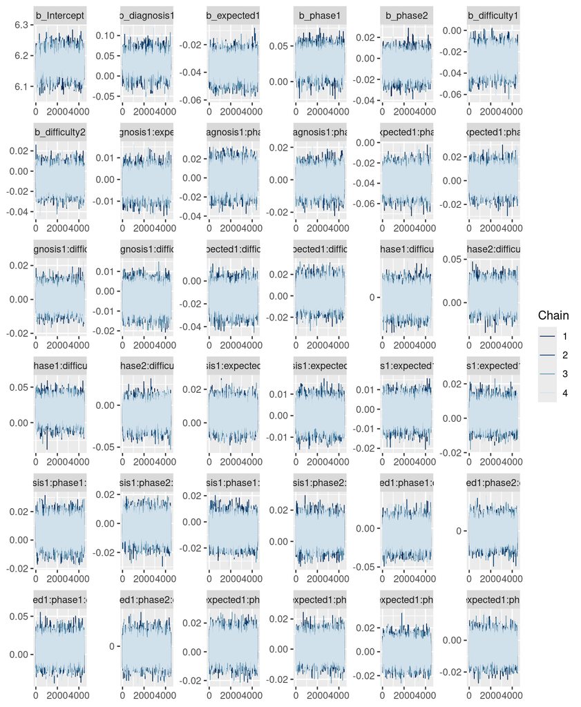

```r
# check the trace plots
post.draws = as_draws_df(m.pal)
mcmc_trace(post.draws, regex_pars = "^b_",
           facet_args = list(ncol = 6)) +
  scale_x_continuous(breaks=scales::pretty_breaks(n = 3)) +
  scale_y_continuous(breaks=scales::pretty_breaks(n = 3))
```

This model has no pathological behaviour with E-BFMI, no divergent sample and no rhats that are higher or equal to 1.01. Therefore, we go ahead and perform our posterior predictive checks.

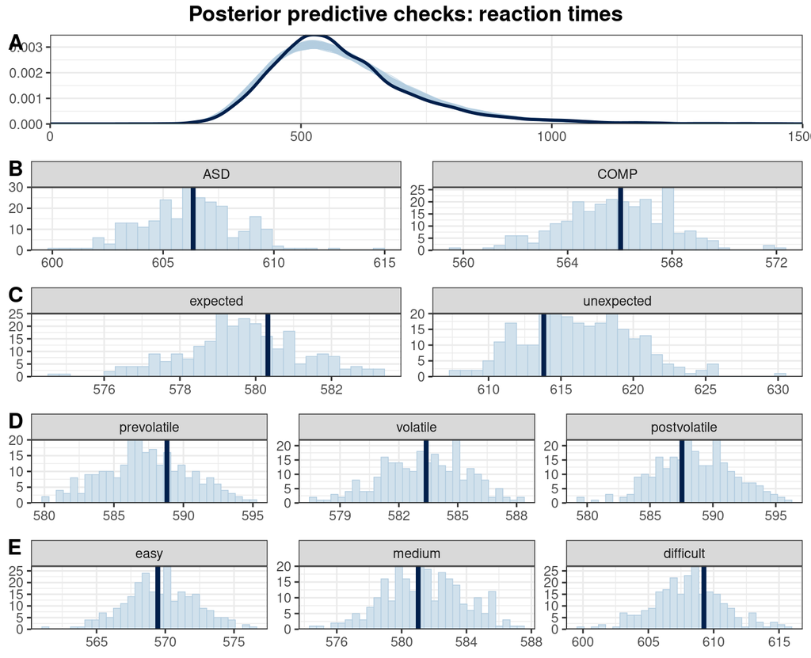

```r
# get posterior predictions
post.pred = posterior_predict(m.pal, ndraws = nsim)

# check the fit of the predicted data compared to the real data
p1 = pp_check(m.pal, ndraws = nsim) +
  theme_bw() + theme(legend.position = "none") + xlim(0, 1500)

# distributions of means compared to the real values per group or conditions
p2 = ppc_stat_grouped(df.pal$rt.cor,
                      post.pred,
                      df.pal$diagnosis) +
  theme_bw() + theme(legend.position = "none")
p3 = ppc_stat_grouped(df.pal$rt.cor,
                      post.pred,
                      df.pal$expected) +
  theme_bw() + theme(legend.position = "none")
p4 = ppc_stat_grouped(df.pal$rt.cor,
                      post.pred,
                      df.pal$phase) +
  theme_bw() + theme(legend.position = "none")
p5 = ppc_stat_grouped(df.pal$rt.cor,
                      post.pred,
                      df.pal$difficulty) +
  theme_bw() + theme(legend.position = "none")

p = ggarrange(p1, p2, p3, p4, p5,
          nrow = 5, ncol = 1, labels = "AUTO")
annotate_figure(p, top = text_grob("Posterior predictive checks: reaction times",
                                   face = "bold", size = 14))
```

The simulated data based on the model fits well with the real data, although there are slight deviations specifically for the predictor expectedness. However, we judge this to be acceptable.

## 2.3 Inferences

Now that we are convinced that we can trust our model, we have a look at its estimate and use the hypothesis function to assess our hypotheses and perform explorative tests.

```r
# print a summary
summary(m.pal)
```

```
##  Family: shifted_lognormal
##   Links: mu = identity; sigma = identity; ndt = identity
## Formula: rt.cor ~ diagnosis * expected * phase * difficulty + (expected * phase * difficulty | subID) + (diagnosis | trl)
##    Data: df.pal (Number of observations: 11207)
##   Draws: 4 chains, each with iter = 6000; warmup = 1500; thin = 1;
##          total post-warmup draws = 18000
##
## Multilevel Hyperparameters:
## ~subID (Number of levels: 44)
##                                                                Estimate
## sd(Intercept)                                                      0.16
## sd(expected1)                                                      0.01
## sd(phase1)                                                         0.06
## sd(phase2)                                                         0.02
## sd(difficulty1)                                                    0.01
## sd(difficulty2)                                                    0.01
## sd(expected1:phase1)                                               0.01
## sd(expected1:phase2)                                               0.01
## sd(expected1:difficulty1)                                          0.00
## sd(expected1:difficulty2)                                          0.01
## sd(phase1:difficulty1)                                             0.01
## sd(phase2:difficulty1)                                             0.01
## sd(phase1:difficulty2)                                             0.01
## sd(phase2:difficulty2)                                             0.01
## sd(expected1:phase1:difficulty1)                                   0.01
## sd(expected1:phase2:difficulty1)                                   0.01
## sd(expected1:phase1:difficulty2)                                   0.01
## sd(expected1:phase2:difficulty2)                                   0.01
## cor(Intercept,expected1)                                          -0.00
## cor(Intercept,phase1)                                             -0.04
## cor(expected1,phase1)                                              0.12
## cor(Intercept,phase2)                                             -0.01
## cor(expected1,phase2)                                             -0.01
## cor(phase1,phase2)                                                -0.14
## cor(Intercept,difficulty1)                                        -0.04
## cor(expected1,difficulty1)                                         0.07
## cor(phase1,difficulty1)                                           -0.16
## cor(phase2,difficulty1)                                            0.01
## cor(Intercept,difficulty2)                                        -0.02
## cor(expected1,difficulty2)                                         0.03
```

[output cut: 1081 more lines]

```
## expected1:phase1:difficulty2            1.00     8608    12268
## expected1:phase2:difficulty2            1.00     8034    10958
## diagnosis1:expected1:phase1:difficulty1 1.00    15527    13584
## diagnosis1:expected1:phase2:difficulty1 1.00    14325    14873
## diagnosis1:expected1:phase1:difficulty2 1.00    16115    14760
## diagnosis1:expected1:phase2:difficulty2 1.00    15825    14645
##
## Further Distributional Parameters:
##       Estimate Est.Error l-95% CI u-95% CI Rhat Bulk_ESS Tail_ESS
## sigma     0.23      0.00     0.22     0.24 1.00    13158    13192
## ndt     100.15      7.50    84.81   114.20 1.00    12727    13392
##
## Draws were sampled using sample(hmc). For each parameter, Bulk_ESS
## and Tail_ESS are effective sample size measures, and Rhat is the potential
## scale reduction factor on split chains (at convergence, Rhat = 1).
```

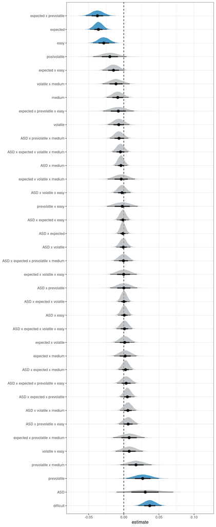

```r
# get the estimates and compute group comparisons
df.m.pal = post.draws %>%
  mutate(
    b_postvolatile = - b_phase1 - b_phase2,
    b_difficult    = - b_difficulty1 - b_difficulty2
  )

# plot the posterior distributions
df.m.pal %>%
  pivot_longer(cols = starts_with("b_"), names_to = "coef", values_to = "estimate") %>%
  subset(!startsWith(coef, "b_Int")) %>%
  mutate(
    coef = substr(coef, 3, nchar(coef)),
    coef = str_replace_all(coef, ":", " x "),
    coef = str_replace_all(coef, "diagnosis1", "ASD"),
    coef = str_replace_all(coef, "expected1", "expected"),
    coef = str_replace_all(coef, "expected2", "unexpected"),
    coef = str_replace_all(coef, "phase1", "prevolatile"),
    coef = str_replace_all(coef, "phase2", "volatile"),
    coef = str_replace_all(coef, "difficulty1", "easy"),
    coef = str_replace_all(coef, "difficulty2", "medium"),
    coef = fct_reorder(coef, desc(estimate))
  ) %>%
  group_by(coef) %>%
  mutate(
    cred = case_when(
      (mean(estimate) < 0 & quantile(estimate, probs = 0.975) < 0) |
        (mean(estimate) > 0 & quantile(estimate, probs = 0.025) > 0) ~ "credible",
      T ~ "not credible"
    )
  ) %>% ungroup() %>%
  ggplot(aes(x = estimate, y = coef, fill = cred)) +
  geom_vline(xintercept = 0, linetype = 'dashed') +
  ggdist::stat_halfeye(alpha = 0.7) + ylab(NULL) + theme_bw() +
  scale_fill_manual(values = c(c_dark, c_light)) + theme(legend.position = "none")
```

```r
## create design matrix to figure out how to set comparisons for hypotheses
df.des = cbind(df.pal %>% select(diagnosis, expected, phase, difficulty),
               model.matrix(~ diagnosis * expected * phase * difficulty,
                            data = df.pal)) %>% distinct()

# H1b: COMP(unexp-exp) > ASD(unexp-exp)
as.data.frame(t(df.des %>%
    group_by(diagnosis, expected) %>%
    summarise(across(where(is.numeric), ~ mean(.x))) %>%
    group_by(diagnosis) %>%
    summarise(across(where(is.numeric), ~ diff(.x))) %>% # unexpected - expected
    select(where(is.numeric)) %>%
    map_df(~ diff(.x)))) %>%
  filter(V1 != 0) # COMP - ASD
```

```
##                      V1
## diagnosis1:expected1  4
```

```r
h1b = hypothesis(m.pal, "0 < diagnosis1:expected1")
h1b
```

```
## Hypothesis Tests for class b:
##                 Hypothesis Estimate Est.Error CI.Lower CI.Upper Evid.Ratio
## 1 (0)-(diagnosis1:e... < 0        0         0    -0.01     0.01       0.58
##   Post.Prob Star
## 1      0.37
## ---
## 'CI': 90%-CI for one-sided and 95%-CI for two-sided hypotheses.
## '*': For one-sided hypotheses, the posterior probability exceeds 95%;
## for two-sided hypotheses, the value tested against lies outside the 95%-CI.
## Posterior probabilities of point hypotheses assume equal prior probabilities.
```

```r
# H1d: COMP(volatile-prevolatile)) < ASD(volatile-prevolatile)
as.data.frame(t(df.des %>%
    filter(phase != "postvolatile") %>%
    group_by(diagnosis, phase) %>%
    summarise(across(where(is.numeric), ~ mean(.x))) %>%
    group_by(diagnosis) %>%
    summarise(across(where(is.numeric), ~ diff(.x))) %>% # volatile - prevolatile
    select(where(is.numeric)) %>%
    map_df(~ diff(.x)))) %>%
  filter(V1 != 0) # COMP - ASD
```

```
##                   V1
## diagnosis1:phase1  2
## diagnosis1:phase2 -2
```

```r
h1d.1 = hypothesis(m.pal, "diagnosis1:phase1 - diagnosis1:phase2 < 0")
h1d.1
```

```
## Hypothesis Tests for class b:
##                 Hypothesis Estimate Est.Error CI.Lower CI.Upper Evid.Ratio
## 1 (diagnosis1:phase... < 0        0      0.01    -0.02     0.02       0.93
##   Post.Prob Star
## 1      0.48
## ---
## 'CI': 90%-CI for one-sided and 95%-CI for two-sided hypotheses.
## '*': For one-sided hypotheses, the posterior probability exceeds 95%;
## for two-sided hypotheses, the value tested against lies outside the 95%-CI.
## Posterior probabilities of point hypotheses assume equal prior probabilities.
```

```r
# H1d: COMP(postvolatile-volatile)) < ASD(postvolatile-volatile)
as.data.frame(t(df.des %>%
    filter(phase != "prevolatile") %>%
    group_by(diagnosis, phase) %>%
    summarise(across(where(is.numeric), ~ mean(.x))) %>%
    group_by(diagnosis) %>%
    summarise(across(where(is.numeric), ~ diff(.x))) %>% # postvolatile - volatile
    select(where(is.numeric)) %>%
    map_df(~ diff(.x)))) %>%
  filter(V1 != 0) # COMP - ASD
```

```
##                   V1
## diagnosis1:phase1  2
## diagnosis1:phase2  4
```

```r
h1d.2 = hypothesis(m.pal, "2*diagnosis1:phase1 + 4*diagnosis1:phase2 < 0")
h1d.2
```

```
## Hypothesis Tests for class b:
##                 Hypothesis Estimate Est.Error CI.Lower CI.Upper Evid.Ratio
## 1 (2*diagnosis1:pha... < 0        0      0.02    -0.04     0.04       1.21
##   Post.Prob Star
## 1      0.55
## ---
## 'CI': 90%-CI for one-sided and 95%-CI for two-sided hypotheses.
## '*': For one-sided hypotheses, the posterior probability exceeds 95%;
## for two-sided hypotheses, the value tested against lies outside the 95%-CI.
## Posterior probabilities of point hypotheses assume equal prior probabilities.
```

```r
## exploration: prevolatile phase

# prevolatile: COMP(unexpected - expected) != ASD(unexpected - expected)
as.data.frame(t(df.des %>%
    filter(phase == "prevolatile") %>%
    group_by(diagnosis, expected) %>%
    summarise(across(where(is.numeric), ~ mean(.x))) %>%
    group_by(diagnosis) %>%
    summarise(across(where(is.numeric), ~ diff(.x))) %>% # unexpected - expected
    select(where(is.numeric)) %>%
    map_df(~ diff(.x)))) %>%
  filter(V1 != 0) # COMP - ASD
```

```
##                             V1
## diagnosis1:expected1         4
## diagnosis1:expected1:phase1  4
```

```r
e1.1 = hypothesis(m.pal, "0 < diagnosis1:expected1 + diagnosis1:expected1:phase1",
                  alpha = 0.025)
e1.1
```

```
## Hypothesis Tests for class b:
##                 Hypothesis Estimate Est.Error CI.Lower CI.Upper Evid.Ratio
## 1 (0)-(diagnosis1:e... < 0        0      0.01    -0.02     0.01        2.5
##   Post.Prob Star
## 1      0.71
## ---
## 'CI': 95%-CI for one-sided and 97.5%-CI for two-sided hypotheses.
## '*': For one-sided hypotheses, the posterior probability exceeds 97.5%;
## for two-sided hypotheses, the value tested against lies outside the 97.5%-CI.
## Posterior probabilities of point hypotheses assume equal prior probabilities.
```

```r
## exploration: task effects

# expected versus unexpected
e2.1 = hypothesis(m.pal, "0 > 2*expected1", alpha = 0.025)
e2.1
```

```
## Hypothesis Tests for class b:
##              Hypothesis Estimate Est.Error CI.Lower CI.Upper Evid.Ratio
## 1 (0)-(2*expected1) > 0     0.07      0.01     0.05      0.1        Inf
##   Post.Prob Star
## 1         1    *
## ---
## 'CI': 95%-CI for one-sided and 97.5%-CI for two-sided hypotheses.
## '*': For one-sided hypotheses, the posterior probability exceeds 97.5%;
## for two-sided hypotheses, the value tested against lies outside the 97.5%-CI.
## Posterior probabilities of point hypotheses assume equal prior probabilities.
```

```r
# volatile versus prevolatile
e2.2 = hypothesis(m.pal, "0 < phase1 - phase2", alpha = 0.025)
e2.2
```

```
## Hypothesis Tests for class b:
##                Hypothesis Estimate Est.Error CI.Lower CI.Upper Evid.Ratio
## 1 (0)-(phase1-phase2) < 0    -0.03      0.02    -0.07        0      62.38
##   Post.Prob Star
## 1      0.98    *
## ---
## 'CI': 95%-CI for one-sided and 97.5%-CI for two-sided hypotheses.
## '*': For one-sided hypotheses, the posterior probability exceeds 97.5%;
## for two-sided hypotheses, the value tested against lies outside the 97.5%-CI.
## Posterior probabilities of point hypotheses assume equal prior probabilities.
```

```r
# volatile versus postvolatile
e2.3 = hypothesis(m.pal, "0 < phase1 + 2*phase2", alpha = 0.025)
e2.3
```

```
## Hypothesis Tests for class b:
##                 Hypothesis Estimate Est.Error CI.Lower CI.Upper Evid.Ratio
## 1 (0)-(phase1+2*pha... < 0    -0.01      0.02    -0.05     0.02       3.46
##   Post.Prob Star
## 1      0.78
## ---
## 'CI': 95%-CI for one-sided and 97.5%-CI for two-sided hypotheses.
## '*': For one-sided hypotheses, the posterior probability exceeds 97.5%;
## for two-sided hypotheses, the value tested against lies outside the 97.5%-CI.
## Posterior probabilities of point hypotheses assume equal prior probabilities.
```

```r
# difficult versus medium
e2.4 = hypothesis(m.pal, "0 < -difficulty1 - 2*difficulty2", alpha = 0.025)
e2.4
```

```
## Hypothesis Tests for class b:
##                 Hypothesis Estimate Est.Error CI.Lower CI.Upper Evid.Ratio
## 1 (0)-(-difficulty1... < 0    -0.05      0.01    -0.07    -0.02        899
##   Post.Prob Star
## 1         1    *
## ---
## 'CI': 95%-CI for one-sided and 97.5%-CI for two-sided hypotheses.
## '*': For one-sided hypotheses, the posterior probability exceeds 97.5%;
## for two-sided hypotheses, the value tested against lies outside the 97.5%-CI.
## Posterior probabilities of point hypotheses assume equal prior probabilities.
```

```r
# medium versus easy
e2.5 = hypothesis(m.pal, "0 < -difficulty1 + difficulty2", alpha = 0.025)
e2.5
```

```
## Hypothesis Tests for class b:
##                 Hypothesis Estimate Est.Error CI.Lower CI.Upper Evid.Ratio
## 1 (0)-(-difficulty1... < 0    -0.02      0.01    -0.05     0.01      12.63
##   Post.Prob Star
## 1      0.93
## ---
## 'CI': 95%-CI for one-sided and 97.5%-CI for two-sided hypotheses.
## '*': For one-sided hypotheses, the posterior probability exceeds 97.5%;
## for two-sided hypotheses, the value tested against lies outside the 97.5%-CI.
## Posterior probabilities of point hypotheses assume equal prior probabilities.
```

```r
# difficult versus easy
e2.6 = hypothesis(m.pal, "0 < -2*difficulty1 - difficulty2", alpha = 0.025)
e2.6
```

```
## Hypothesis Tests for class b:
##                 Hypothesis Estimate Est.Error CI.Lower CI.Upper Evid.Ratio
## 1 (0)-(-2*difficult... < 0    -0.07      0.01    -0.09    -0.04        Inf
##   Post.Prob Star
## 1         1    *
## ---
## 'CI': 95%-CI for one-sided and 97.5%-CI for two-sided hypotheses.
## '*': For one-sided hypotheses, the posterior probability exceeds 97.5%;
## for two-sided hypotheses, the value tested against lies outside the 97.5%-CI.
## Posterior probabilities of point hypotheses assume equal prior probabilities.
```

```r
## extract predicted differences in ms instead of log data
df.new = df.pal %>%
  select(diagnosis, phase, expected, difficulty) %>%
  distinct() %>%
  mutate(
    condition = paste(diagnosis, phase, expected, difficulty, sep = "_")
  )
df.ms = as.data.frame(
  fitted(m.pal, summary = F,
               newdata = df.new %>% select(diagnosis, phase, expected, difficulty),
               re_formula = NA))
colnames(df.ms) = df.new$condition

# calculate our difference columns
df.ms = df.ms %>%
  mutate(
    COMP_expected     = rowMeans(across(matches("COMP_.*_expected_.*"))),
    COMP_unexpected   = rowMeans(across(matches("COMP_.*_unexpected_.*"))),
    ASD_expected      = rowMeans(across(matches("ASD_.*_expected_.*"))),
    ASD_unexpected    = rowMeans(across(matches("ASD_.*_unexpected_.*"))),
    COMP_unexp_exp    = COMP_unexpected - COMP_expected,
    ASD_unexp_exp     = ASD_unexpected  - ASD_expected,
    `h1b_COMP-ASD unexpected-expected`  = COMP_unexp_exp - ASD_unexp_exp,
    ASD_prevolatile   = rowMeans(across(matches("ASD_prevolatile_.*"))),
    ASD_volatile      = rowMeans(across(matches("ASD_volatile_.*"))),
    COMP_prevolatile  = rowMeans(across(matches("COMP_prevolatile_.*"))),
    COMP_volatile     = rowMeans(across(matches("COMP_volatile_.*"))),
    ASD_postvolatile  = rowMeans(across(matches("ASD_postvolatile_.*"))),
    COMP_postvolatile = rowMeans(across(matches("COMP_postvolatile_.*"))),
    `h1d_ASD-COMP volatile-prevolatile` =
      (ASD_volatile - ASD_prevolatile) - (COMP_volatile - COMP_prevolatile),
    `h1d_ASD-COMP postvolatile-volatile` =
      (ASD_postvolatile - ASD_volatile) - (COMP_postvolatile - COMP_volatile),
    COMP_pre_unexp    = rowMeans(across(matches("COMP_prevolatile_unexpected_.*"))),
    COMP_pre_exp      = rowMeans(across(matches("COMP_prevolatile_expected_.*"))),
    ASD_pre_unexp     = rowMeans(across(matches("ASD_prevolatile_unexpected_.*"))),
    ASD_pre_exp       = rowMeans(across(matches("ASD_prevolatile_expected_.*"))),
    `e11_prevolatile COMP-ASD unexpected-expected` =
      (COMP_pre_unexp - COMP_pre_exp) - (ASD_pre_unexp - ASD_pre_exp),
    `e21_unexpected-expected`           = rowMeans(across(matches(".*_unexpected_.*"))) -
      rowMeans(across(matches(".*_expected_.*"))),
    `e22_volatile-prevolatile`       = rowMeans(across(matches(".*_volatile_.*"))) -
      rowMeans(across(matches(".*_prevolatile_.*"))),
    `e23_volatile-postvolatile`      = rowMeans(across(matches(".*_volatile_.*"))) -
      rowMeans(across(matches(".*_postvolatile_.*"))),
    `e24_difficult-medium`      = rowMeans(across(matches(".*_difficult"))) -
      rowMeans(across(matches(".*_medium"))),
    `e25_medium-easy`      = rowMeans(across(matches(".*_medium"))) -
      rowMeans(across(matches(".*_easy"))),
    `e26_difficult-easy`     = rowMeans(across(matches(".*_difficult"))) -
      rowMeans(across(matches(".*_easy")))
  )

kable(df.ms %>%
  select(starts_with("e") | starts_with("h")) %>%
  summarise_all(list(lower_ci = lower_ci, mean = mean, upper_ci = upper_ci)) %>%
  t %>%
  as.data.frame %>%
  rownames_to_column() %>%
  separate(rowname, into = c("id", "comparison", "stat"), sep = "_") %>%
  pivot_wider(names_from = stat, values_from = V1) %>%
  arrange(comparison), digits = 2)
```

[output not shown]

```r
equivalence_test(df.ms %>% select(starts_with("h")),
                 range = rope_range(m.pal))
```

```
## # Test for Practical Equivalence
##
##   ROPE: [-15.04 15.04]
##
## Parameter                          |        H0 | inside ROPE |         95% HDI
## ------------------------------------------------------------------------------
## h1COMP-ASD unexpected-expected     | Undecided |     92.70 % | [-20.23, 11.10]
## h1d_ASD-COMP volatile-prevolatile  | Undecided |     81.47 % | [-26.02, 22.77]
## h1d_ASD-COMP postvolatile-volatile | Undecided |     82.92 % | [-23.02, 25.14]
```

```r
# calculate effect sizes
df.effect = df.m.pal %>%
  mutate(across(starts_with("sd")|starts_with("sigma"), ~.^2)) %>%
  mutate(
    sumvar = sqrt(rowSums(select(., starts_with("sd")|starts_with("sigma")))),
    h1b    = 4*`b_diagnosis1:expected1` / sumvar,
    h1d.1  = 2*(`b_diagnosis1:phase1` - `b_diagnosis1:phase2`) / sumvar,
    h1d.2  = 2*(`b_diagnosis1:phase1` + 2*`b_diagnosis1:phase2`) / sumvar,
    e.exp  = -2*b_expected1 / sumvar,
    e.dif  = (-2*b_difficulty1 - b_difficulty2) / sumvar
  )

kable(df.effect %>% select(starts_with("e.")|starts_with("h")) %>%
        pivot_longer(cols = everything(), values_to = "estimate") %>%
        group_by(name) %>%
        summarise(
          ci.lo = lower_ci(estimate),
          mean  = mean(estimate),
          ci.hi = upper_ci(estimate),
          interpret = interpret_cohens_d(mean)
        ), digits = 3
)
```

| name | ci.lo | mean | ci.hi | interpret |
| --- | --- | --- | --- | --- |
| e.dif | 0.126 | 0.222 | 0.318 | small |
| e.exp | 0.162 | 0.245 | 0.329 | small |
| h1b | -0.122 | -0.018 | 0.087 | very small |
| h1d.1 | -0.155 | 0.005 | 0.167 | very small |
| h1d.2 | -0.177 | -0.009 | 0.157 | very small |

H1b: *estimate* = 0 [-0.01, 0.01], *posterior probability* = 36.57%

H1c pre to vol: *estimate* = 0 [-0.02, 0.02], *posterior probability* = 48.31%

H1c vol to post: *estimate* = 0 [-0.04, 0.04], *posterior probability* = 54.78%

Expectancy: *estimate* = 0.07 [0.05, 0.1], *posterior probability* = 100%

Difficult - easy: *estimate* = -0.07 [-0.09, -0.04], *posterior probability* = 100%

## 2.4 Plots

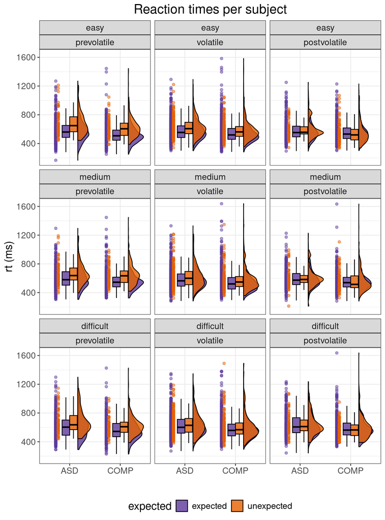

```r
# rain cloud plot including all factors

df.pal %>%
  ggplot(aes(diagnosis, rt.cor, fill = expected, colour = expected)) + #
  geom_rain(rain.side = 'r',
boxplot.args = list(color = "black", outlier.shape = NA, show.legend = FALSE, alpha = .8),
violin.args = list(color = "black", outlier.shape = NA, alpha = .8),
boxplot.args.pos = list(
  position = ggpp::position_dodgenudge(x = 0, width = 0.3), width = 0.3
),
point.args = list(show_guide = FALSE, alpha = .5),
violin.args.pos = list(
  width = 0.6, position = position_nudge(x = 0.16)),
point.args.pos = list(position = ggpp::position_dodgenudge(x = -0.25, width = 0.1))) +
  scale_fill_manual(values = col.cnd) +
  scale_color_manual(values = col.cnd) +
  #ylim(0, 1) +
  labs(title = "Reaction times per subject", x = "", y = "rt (ms)") +
  facet_wrap(difficulty ~ phase) +
  theme_bw() +
  theme(legend.position = "bottom", plot.title = element_text(hjust = 0.5),
        legend.direction = "horizontal", text = element_text(size = 15))
```

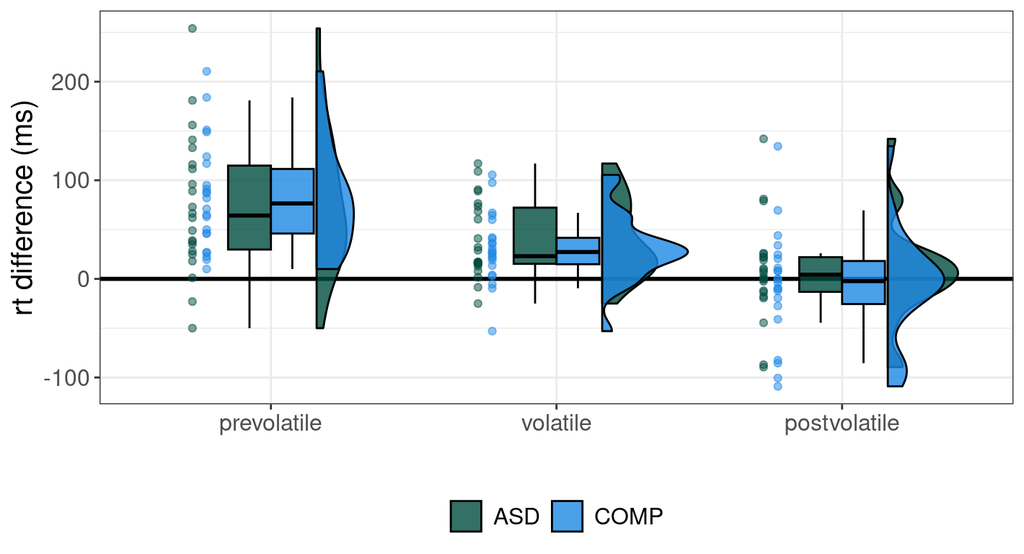

```r
# rain cloud plot focusing on the effect of expectancy
df.pal %>%
  group_by(subID, diagnosis, expected, phase) %>%
  summarise(
    rt.cor = median(rt.cor, na.rm = T)
  ) %>%
  group_by(subID, diagnosis, phase) %>%
  summarise(
    rt.exp = diff(rt.cor)
  ) %>%
  ggplot(aes(phase, rt.exp, fill = diagnosis, colour = diagnosis)) + #
  geom_hline(yintercept = 0, linewidth = 1) +
  geom_rain(rain.side = 'r',
boxplot.args = list(color = "black", outlier.shape = NA, show.legend = FALSE, alpha = .8),
violin.args = list(color = "black", outlier.shape = NA, alpha = .8),
boxplot.args.pos = list(
  position = ggpp::position_dodgenudge(x = 0, width = 0.3), width = 0.3
),
point.args = list(show_guide = FALSE, alpha = .5),
violin.args.pos = list(
  width = 0.6, position = position_nudge(x = 0.16)),
point.args.pos = list(position = ggpp::position_dodgenudge(x = -0.25, width = 0.1))) +
  scale_fill_manual(values = col.grp) +
  scale_color_manual(values = col.grp) +
  #ylim(0, 1) +
  labs(title = "", x = "", y = "rt difference (ms)") +
  theme_bw() +
  theme(legend.position = "bottom", plot.title = element_blank(),
        legend.direction = "horizontal", text = element_text(size = 15),
        legend.title = element_blank())
```

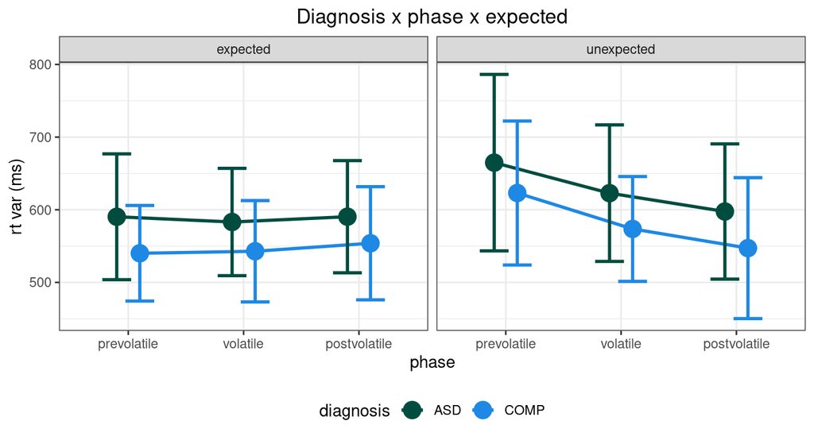

```r
ggsave("plots/FigRT.svg", units = "cm", width = 18, height = 9)

# plot transition effects specifically
df.pal %>%
  group_by(subID, diagnosis, phase, expected) %>%
  summarise(rt.cor = median(rt.cor, na.rm = T)) %>%
  group_by(diagnosis, phase, expected) %>%
  summarise(
    rt.mn = mean(rt.cor),
    rt.se = sd(rt.cor)
  ) %>%
  ggplot(aes(y = rt.mn, x = phase,
             group = diagnosis, colour = diagnosis)) +
  geom_line(position = position_dodge(0.4), linewidth = 1) +
  geom_errorbar(aes(ymin = rt.mn - rt.se,
                    ymax = rt.mn + rt.se), linewidth = 1, width = 0.5,
                position = position_dodge(0.4)) +
  geom_point(position = position_dodge(0.4), size = 5) +
  labs (x = "phase", y = "rt var (ms)") +
  ggtitle("Diagnosis x phase x expected") +
  facet_wrap(. ~ expected) +
  scale_fill_manual(values = col.grp) +
  scale_color_manual(values = col.grp) +
  theme_bw() +
  theme(legend.position = "bottom", plot.title = element_text(hjust = 0.5))
```

# 3 Explorative analysis of errors

Last but not least, we are going to explore possible differences with regards to mean accuracies using a Bayesian ANOVA.

```r
# create accuracies dataframe
df.acc = df.tsk %>% filter(expected != "neutral") %>% droplevels() %>%
  group_by(subID, diagnosis, phase, expected, difficulty) %>%
  summarise(acc = mean(acc)*100)

# check normal distribution
kable(df.tsk %>% group_by(subID, diagnosis, phase, expected, difficulty) %>%
  summarise(acc = mean(acc)*100) %>%
  group_by(diagnosis, phase, expected, difficulty) %>%
  shapiro_test(acc) %>%
    mutate(
      sig = if_else(p < 0.05, "*", "")
    ))
```

| diagnosis | phase | expected | difficulty | variable | statistic | p | sig |
| --- | --- | --- | --- | --- | --- | --- | --- |
| ASD | prevolatile | expected | easy | acc | 0.7899150 | 0.0003493 | * |
| ASD | prevolatile | expected | medium | acc | 0.8196518 | 0.0010329 | * |
| ASD | prevolatile | expected | difficult | acc | 0.9513117 | 0.3352573 |  |
| ASD | prevolatile | unexpected | easy | acc | 0.7300861 | 0.0000485 | * |
| ASD | prevolatile | unexpected | medium | acc | 0.5427260 | 0.0000003 | * |
| ASD | prevolatile | unexpected | difficult | acc | 0.7384827 | 0.0000630 | * |
| ASD | volatile | expected | easy | acc | 0.6635127 | 0.0000070 | * |
| ASD | volatile | expected | medium | acc | 0.8229961 | 0.0011725 | * |
| ASD | volatile | expected | difficult | acc | 0.8818798 | 0.0131241 | * |
| ASD | volatile | neutral | easy | acc | 0.6266742 | 0.0000026 | * |
| ASD | volatile | neutral | medium | acc | 0.6941979 | 0.0000165 | * |
| ASD | volatile | neutral | difficult | acc | 0.9542600 | 0.3825536 |  |
| ASD | volatile | unexpected | easy | acc | 0.6556744 | 0.0000056 | * |
| ASD | volatile | unexpected | medium | acc | 0.7900701 | 0.0003513 | * |
| ASD | volatile | unexpected | difficult | acc | 0.7696377 | 0.0001738 | * |
| ASD | postvolatile | expected | easy | acc | 0.6991366 | 0.0000191 | * |
| ASD | postvolatile | expected | medium | acc | 0.8071926 | 0.0006498 | * |
| ASD | postvolatile | expected | difficult | acc | 0.9264805 | 0.1036401 |  |
| ASD | postvolatile | unexpected | easy | acc | 0.6048243 | 0.0000015 | * |
| ASD | postvolatile | unexpected | medium | acc | 0.7384827 | 0.0000630 | * |
| ASD | postvolatile | unexpected | difficult | acc | 0.7949289 | 0.0004172 | * |
| COMP | prevolatile | expected | easy | acc | 0.6048243 | 0.0000015 | * |
| COMP | prevolatile | expected | medium | acc | 0.6717248 | 0.0000087 | * |
| COMP | prevolatile | expected | difficult | acc | 0.9220654 | 0.0838957 |  |
| COMP | prevolatile | unexpected | easy | acc | 0.5904384 | 0.0000010 | * |
| COMP | prevolatile | unexpected | medium | acc | 0.5555850 | 0.0000005 | * |
| COMP | prevolatile | unexpected | difficult | acc | 0.8469958 | 0.0030052 | * |
| COMP | volatile | expected | easy | acc | 0.8053882 | 0.0006083 | * |
| COMP | volatile | expected | medium | acc | 0.7784453 | 0.0002345 | * |
| COMP | volatile | expected | difficult | acc | 0.8934097 | 0.0219914 | * |
| COMP | volatile | neutral | easy | acc | 0.6048243 | 0.0000015 | * |
| COMP | volatile | neutral | medium | acc | 0.7416438 | 0.0000696 | * |
| COMP | volatile | neutral | difficult | acc | 0.8721173 | 0.0085735 | * |
| COMP | volatile | unexpected | easy | acc | 0.6046337 | 0.0000015 | * |
| COMP | volatile | unexpected | medium | acc | 0.6449235 | 0.0000042 | * |
| COMP | volatile | unexpected | difficult | acc | 0.7733926 | 0.0001974 | * |
| COMP | postvolatile | expected | easy | acc | 0.6488874 | 0.0000047 | * |
| COMP | postvolatile | expected | medium | acc | 0.7015343 | 0.0000205 | * |
| COMP | postvolatile | expected | difficult | acc | 0.8164406 | 0.0009154 | * |
| COMP | postvolatile | unexpected | easy | acc | 0.4735522 | 0.0000001 | * |
| COMP | postvolatile | unexpected | medium | acc | 0.4225841 | 0.0000000 | * |
| COMP | postvolatile | unexpected | difficult | acc | 0.7202060 | 0.0000358 | * |

```r
# rank transform the data
df.acc = df.acc %>%
  ungroup() %>%
  mutate(
    racc   = rank(acc)
    )

# run the ANOVA
if (!file.exists(file.path(brms_dir, "aov_acc.rds"))){
  aov.acc   = anovaBF(racc   ~ diagnosis * phase * expected * difficulty, data = df.acc)
  saveRDS(aov.acc, file = file.path(brms_dir, "aov_acc.rds"))
} else {
  aov.acc = readRDS(file.path(brms_dir, "aov_acc.rds"))
}

bf.acc = extractBF(aov.acc, logbf = T)
kable(head(bf.acc %>% arrange(desc(bf))))
```

|  | bf | error | time | code |
| --- | --- | --- | --- | --- |
| diagnosis + expected + difficulty | 41.14776 | 0.0183230 | Fri Sep 5 11:41:24 2025 | ebb211aed3f |
| diagnosis + difficulty | 40.82967 | 0.0142911 | Fri Sep 5 11:41:23 2025 | ebb6c8d5fa8 |
| diagnosis + expected + diagnosis:expected + difficulty | 40.29352 | 0.0253077 | Fri Sep 5 11:41:24 2025 | ebb44e2efaa |
| diagnosis + expected + difficulty + diagnosis:difficulty | 39.74004 | 0.0232809 | Fri Sep 5 11:41:26 2025 | ebb4e982c80 |
| diagnosis + difficulty + diagnosis:difficulty | 39.38857 | 0.0180471 | Fri Sep 5 11:41:26 2025 | ebb1dcbd616 |
| diagnosis + expected + diagnosis:expected + difficulty + diagnosis:difficulty | 38.93077 | 0.0403093 | Fri Sep 5 11:41:27 2025 | ebb18fd4334 |

```r
# print overall accuracy rates for all the effects included in the best model
df.acc %>%
  group_by(diagnosis, difficulty, expected) %>%
  summarise(mean_accuracy = mean(acc, na.rm = T),
            sd_accuracy = sd(acc, na.rm = T))
```

```
## # A tibble: 12 × 5
## # Groups:   diagnosis, difficulty [6]
##    diagnosis difficulty expected   mean_accuracy sd_accuracy
##    <fct>     <fct>      <fct>              <dbl>       <dbl>
##  1 ASD       easy       expected            93.4        8.88
##  2 ASD       easy       unexpected          89.6       17.1
##  3 ASD       medium     expected            91.6        9.14
##  4 ASD       medium     unexpected          88.4       16.9
##  5 ASD       difficult  expected            84.9       10.9
##  6 ASD       difficult  unexpected          84.5       17.5
##  7 COMP      easy       expected            97.9        3.23
##  8 COMP      easy       unexpected          93.9       10.8
##  9 COMP      medium     expected            96.3        5.34
## 10 COMP      medium     unexpected          94.7       11.4
## 11 COMP      difficult  expected            89.8        8.68
## 12 COMP      difficult  unexpected          84.8       16.6
```

```r
df.acc %>%
  group_by(diagnosis) %>%
  summarise(mean_accuracy = mean(acc, na.rm = T),
            sd_accuracy = sd(acc, na.rm = T))
```

```
## # A tibble: 2 × 3
##   diagnosis mean_accuracy sd_accuracy
##   <fct>             <dbl>       <dbl>
## 1 ASD                88.7        14.2
## 2 COMP               92.9        11.1
```

```r
df.acc %>%
  group_by(expected) %>%
  summarise(mean_accuracy = mean(acc, na.rm = T),
            sd_accuracy = sd(acc, na.rm = T))
```

```
## # A tibble: 2 × 3
##   expected   mean_accuracy sd_accuracy
##   <fct>              <dbl>       <dbl>
## 1 expected            92.3        9.15
## 2 unexpected          89.3       15.7
```

```r
df.acc %>%
  group_by(difficulty) %>%
  summarise(mean_accuracy = mean(acc, na.rm = T),
            sd_accuracy = sd(acc, na.rm = T))
```

```
## # A tibble: 3 × 3
##   difficulty mean_accuracy sd_accuracy
##   <fct>              <dbl>       <dbl>
## 1 easy                93.7        11.5
## 2 medium              92.8        11.8
## 3 difficult           86.0        14.1
```

Accuracies were generally high, with a grand average of 90.82% accurate responses across diagnostic groups. Accuracies seems to have differed between diagnostic groups. Let’s do some plotting to figure out where our differences lie.

## 3.1 Plots

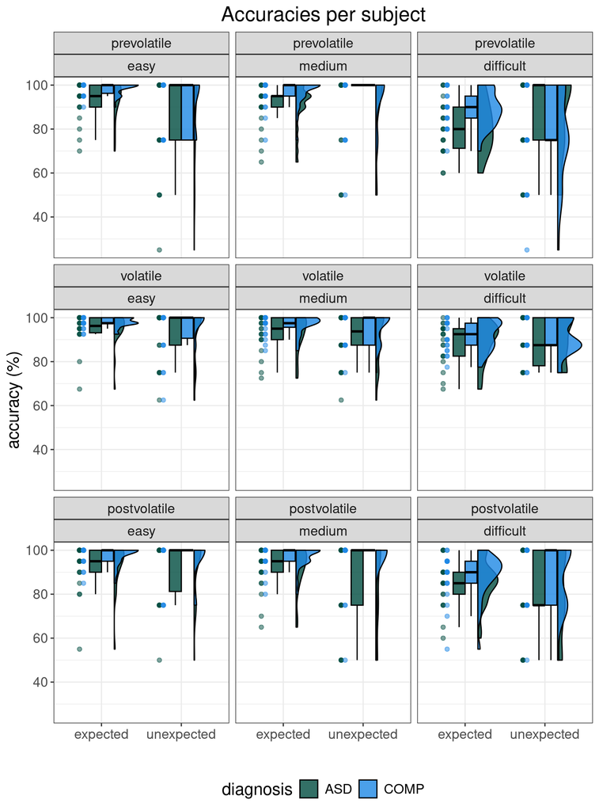

```r
# rain cloud plot including all factors

df.acc %>%
  ggplot(aes(expected, acc, fill = diagnosis, colour = diagnosis)) + #
  geom_rain(rain.side = 'r',
boxplot.args = list(color = "black", outlier.shape = NA, show.legend = FALSE, alpha = .8),
violin.args = list(color = "black", outlier.shape = NA, alpha = .8),
boxplot.args.pos = list(
  position = ggpp::position_dodgenudge(x = 0, width = 0.3), width = 0.3
),
point.args = list(show_guide = FALSE, alpha = .5),
violin.args.pos = list(
  width = 0.6, position = position_nudge(x = 0.16)),
point.args.pos = list(position = ggpp::position_dodgenudge(x = -0.25, width = 0.1))) +
  scale_fill_manual(values = col.grp) +
  scale_color_manual(values = col.grp) +
  labs(title = "Accuracies per subject", x = "", y = "accuracy (%)") +
  facet_wrap(phase ~ difficulty) +
  theme_bw() +
  theme(legend.position = "bottom", plot.title = element_text(hjust = 0.5),
        legend.direction = "horizontal", text = element_text(size = 15))
```

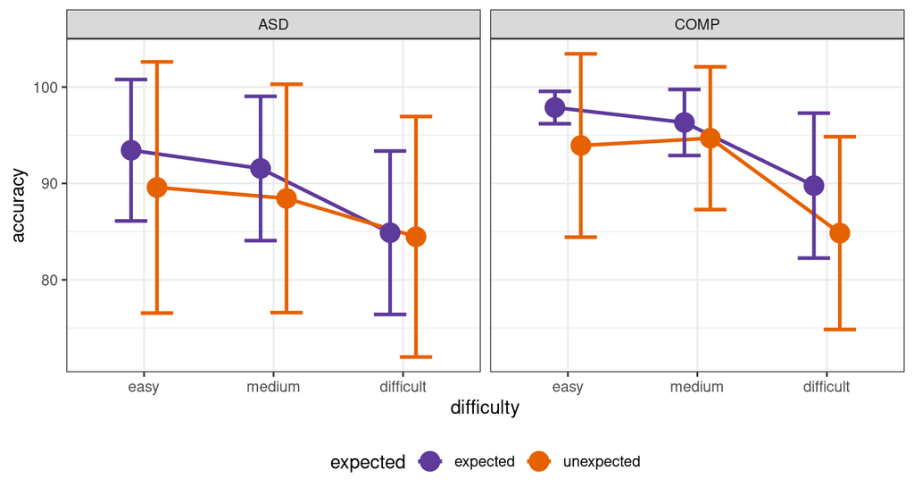

```r
# plot as line plot without the phases
df.acc %>%
  group_by(subID, diagnosis, expected, difficulty) %>%
  summarise(
    acc = mean(acc, na.rm = T)
  ) %>%
  group_by(diagnosis, expected, difficulty) %>%
  summarise(
    acc.mn = mean(acc),
    acc.se = sd(acc)
  ) %>%
  ggplot(aes(y = acc.mn, x = difficulty, group = expected, colour = expected)) +
  geom_line(position = position_dodge(0.4), linewidth = 1) +
  geom_errorbar(aes(ymin = acc.mn - acc.se,
                    ymax = acc.mn + acc.se), linewidth = 1, width = 0.5,
                position = position_dodge(0.4)) +
  geom_point(position = position_dodge(0.4), size = 5) +
  facet_wrap(. ~ diagnosis) +
  #ylim(75,100) +
  labs (x = "difficulty", y = "accuracy") +
  scale_fill_manual(values = col.cnd) +
  scale_color_manual(values = col.cnd) +
  theme_bw() +
  theme(legend.position = "bottom", plot.title = element_text(hjust = 0.5))
```